# Cardiac Arrhythmia Diagnosis

- **Author**: [Andy Wang](https://www.linkedin.com/in/andy-wang-3b595a299/), Johns Hopkins University, Class of 2027
- **Github Repository**: https://github.com/sirandy3000/projects/tree/master/ecg

## Abstract

> This Jupyter notebook contains my implementation of a Cardiac Arrhythmia diagnosis system using machine learning models trained on processed electrocardiogram signals. The 96 half-hour long signals were obtained from 47 patients at the BID Medical Center in Boston from 1975 to 1979; the signals were published as part of the MIT-BIH Arrhythmia Database in 2005. To create the diagnosis system, I first cleaned the data, reshaping it into a tabular format and discarding outlier instances. I then engineered features by extracting individual heartbeats from the signals, before performing Principal Component Analysis on the dataset. Finally, I performed cross-validation on several models, fine-tuned the hyperparameters of the best performers, and combined their performance into a single model through ensembling.

## Contents

1. Project Setup
2. Data Preprocessing
3. Modeling
4. Evaluation

## 1. Project Setup

In this section, I import required packages and download the dataset.

### 1.1) Package Import

```python
import os
import urllib
import zipfile

import numpy as np
import pandas as pd
import matplotlib.pyplot as plt
```

```python
import biosppy.signals.ecg as ecg
import wfdb

from sklearn.decomposition import PCA
from sklearn.ensemble import (
    GradientBoostingClassifier, RandomForestClassifier,
    StackingClassifier, VotingClassifier
)
from sklearn.linear_model import LogisticRegression
from sklearn.metrics import f1_score
from sklearn.model_selection import (
    cross_val_predict, cross_val_score,
    RandomizedSearchCV, train_test_split
)
from sklearn.preprocessing import MinMaxScaler
from sklearn.pipeline import make_pipeline
from sklearn.svm import SVC
```

### 1.2) Data Download

I download the dataset from [Physionet](https://physionet.org), a public repository for signal data managed by MIT. The dataset arrives as a Zipfile, from which I extract the records in `download_ecg_database()`. Each individual record belongs to a single patient and consists of four files: *.atr*, *.dat*, *.hea*, and *.xws*. I use the *wfdb* (Waveform Database) library to read the records: `wfdb.rdsamp()` reads the signals, while `wfdb.rdann()` reads the labels.

```python
PATIENT_IDS = [100, 101, 102, 103, 104, 105, 106, 107, 108, 109, 111, 112, 113, 114, 115, 116, 117, 118, 119, 121, 122, 123, 124, 200, 201, 202, 203, 205, 207, 208, 209, 210, 212, 213, 214, 215, 217, 219, 220, 221, 222, 223, 228, 230, 231, 232, 233, 234]
PATIENT_IDS = [str(p) for p in PATIENT_IDS]

def download_ecg_database():
    url = "https://physionet.org/static/published-projects/mitdb/mit-bih-arrhythmia-database-1.0.0.zip"
    dest = "ecg.zip"
    urllib.request.urlretrieve(url, dest)
    with zipfile.ZipFile(dest, "r") as zf:
        zf.extractall(".")
    os.rename("mit-bih-arrhythmia-database-1.0.0", "ecg")
    os.remove(dest)

def load_ecg_records():
    global PATIENT_IDS
    return {p: wfdb.rdsamp(os.path.join("ecg", p)) for p in PATIENT_IDS}

def load_ecg_labels():
    global PATIENT_IDS
    return {p: wfdb.rdann(os.path.join("ecg", p), "atr") for p in PATIENT_IDS}
```

```python
download_ecg_database()
records = load_ecg_records()
labels  = load_ecg_labels()
```

```python
print(f"The dataset contains of {len(records)} records.")
```

```
The dataset contains of 48 records.
```

## 2. Data Preprocessing

In this section, I preprocess the dataset, including:

- Tabulating records
- Extracting heartbeats
- Transforming inconsistent records
- Splitting data into training and evaluation sets
- Performing Principal Component Analysis

### 2.1) Tabulation

The records are currently irregularly stored and should be reshaped into a rectangular format. The first element of each record is an array with two columns, where each column represents the signal from a single channel (i.e. *MLII* or *V5*); the channel names are stored in the `sig_name` field of the second element. I tabulated the records such that each row contains a signal from one patient and one channel.

```python
records["100"]
```

```
(array([[-0.145, -0.065],
        [-0.145, -0.065],
        [-0.145, -0.065],
        ...,
        [-0.675, -0.365],
        [-0.765, -0.335],
        [-1.28 ,  0.   ]]),
 {'fs': 360,
  'sig_len': 650000,
  'n_sig': 2,
  'base_date': None,
  'base_time': None,
  'units': ['mV', 'mV'],
  'sig_name': ['MLII', 'V5'],
  'comments': ['69 M 1085 1629 x1', 'Aldomet, Inderal']})
```

```python
def tabulate_records(records):
    new_records = []
    for patient, record in records.items():
        for i, channel in enumerate(record[1]["sig_name"]):
            new_records.append([patient, channel, record[0].transpose()[i]])
    return new_records
```

```python
records = tabulate_records(records)
records[:2]
```

```
[['100', 'MLII', array([-0.145, -0.145, -0.145, ..., -0.675, -0.765, -1.28 ])],
 ['100', 'V5', array([-0.065, -0.065, -0.065, ..., -0.365, -0.335,  0.   ])]]
```

Meanwhile, the labels are stored as *wfdb Annotation* objects; the *symbol* field contains the label assigned to each heartbeat, while the *sample* field contains the time each heartbeat was measured. I tabulated the labels such that each row contains the *samples* and *symbols* of one patient.

```python
type(labels["100"])
```

```
wfdb.io.annotation.Annotation
```

```python
np.array(labels["100"].symbol), labels["100"].sample
```

```
(array(['+', 'N', 'N', ..., 'N', 'N', 'N'], dtype='<U1'),
 array([    18,     77,    370, ..., 649484, 649734, 649991]))
```

```python
def tabulate_labels(labels):
    new_labels = []
    for patient, label in labels.items():
        new_labels.append([patient, label.sample, np.array(label.symbol)])
    return new_labels
```

```python
labels = tabulate_labels(labels)
labels[:1]
```

```
[['100',
  array([    18,     77,    370, ..., 649484, 649734, 649991]),
  array(['+', 'N', 'N', ..., 'N', 'N', 'N'], dtype='<U1')]]
```

### 2.2) Heartbeat Extraction

The plot below shows heartbeats from the first 5 seconds of the first signal in *records*. Each beat will become one instance in the processed dataset; this is achieved using the *ecg* function from the *biosppy* (Biosignal Processing in Python) library, which finds the *R-peaks* in the signals. *R-peaks* are essentially the heartbeats' upper peaks; the signal values between one *R-peak* and the next will constitute one beat.

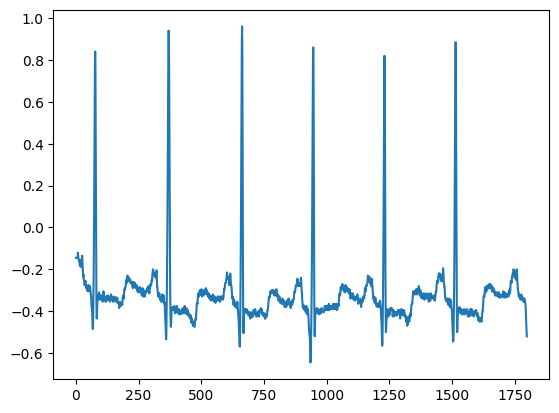

```python
plt.plot(np.arange(1800), records[0][2][:1800])
plt.show()
```

```python
def extract_heartbeats(signal):
    rpeaks = ecg.ecg(signal, sampling_rate=360, show=False)["rpeaks"]
    return np.split(signal, rpeaks)[1:-1]
```

```python
beats = extract_heartbeats(records[0][2])
len(beats), len(labels[0][2])
```

```
(2271, 2274)
```

### 2.3) Label Correction

Shown above, the number of extracted heartbeats differs slightly from the number of provided labels. After extracting the beats of all patients across all channels, I found, as shown below, that the number of labels almost always exceeds the number of beats, sometimes dramatically.

```python
def plot_difference_distribution(records, labels):
    differences = []
    for i, record in enumerate(records):
        beats = extract_heartbeats(record[2])
        differences.append(len(labels[i // 2][2]) - len(beats))
    plt.hist(differences)
    plt.xlabel("Number of Extra Labels")
    plt.show()
```

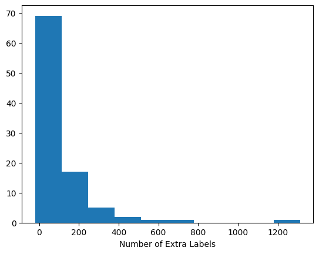

```python
plot_difference_distribution(records, labels)
```

After finding no clarification from the database's [description](https://archive.physionet.org/physiobank/database/html/mitdbdir/mitdbdir.htm), I discarded the records where the difference exceeded 100 labels, and dropped the extra labels otherwise.

```python
def adjust_labels(records, labels):
    new_data = []
    for i, record in enumerate(records):
        beats = extract_heartbeats(record[2])
        label = labels[i // 2][2]
        difference = len(label) - len(beats)

        if not difference:
            new_data.append(record + [label])
        elif 0 < difference < 100:
            new_data.append(record + [label[:-difference]])
    return new_data
```

```python
data = adjust_labels(records, labels)
```

```python
data[:1]
```

```
[['100',
  'MLII',
  array([-0.145, -0.145, -0.145, ..., -0.675, -0.765, -1.28 ]),
  array(['+', 'N', 'N', ..., 'N', 'N', 'N'], dtype='<U1')]]
```

### 2.4) DataFrame Construction

Next, I constructed a DataFrame using the dataset, where each instance (row) represents one heartbeat. Different beats have different durations, so I recorded each beat as exactly 1 second long - almost all beats were shorter. The ECG sampling rate is 360Hz, meaning the DataFrame contains "360" features - the signal values at each of the 360 frames. I discarded heartbeats exceeding 1 second in length, and padded those shorter than 1 second with zeros. Meanwhile, the label values are single characters: *N* represents a normal beat, while all other characters represent an anomaly. To simplify modeling, I used a binary classification task - to predict where the beat is normal. The final DataFrame consists of the 360 features, labels, patient IDs, and channel names: the latter 2 fields are for diagnosing patients and are excluded from modeling.

```python
def engineer_heartbeats(signal, labels):
    beats = extract_heartbeats(signal)
    new_data, new_labels = [], []
    for i, beat in enumerate(beats):
        if len(beat) <= 360:
            new_data.append(np.pad(beat, (0, 360 - len(beat))))
            new_labels.append(labels[i])
    return pd.DataFrame(new_data), pd.Series(new_labels)
```

```python
def construct_dataframe(data):
    colnames = ["patient", "channel", "abnormal"] + list(range(360))
    new_data = pd.DataFrame(columns=colnames)
    for patient, channel, signal, labels in data:
        df, new_labels = engineer_heartbeats(signal, labels)
        df.insert(0, "patient", patient)
        df.insert(1, "channel", channel)
        df.insert(2, "abnormal", (new_labels != "N").astype(int))
        new_data = pd.concat([new_data, df])
    return new_data
```

```python
data = construct_dataframe(data)
```

```python
print(f"The dataset contains {data.shape[0]} heartbeats.")
```

```
The dataset contains 116942 heartbeats.
```

```python
data.head()
```

|  | patient | channel | abnormal | 0 | 1 | 2 | 3 | 4 | 5 | 6 | ... | 350 | 351 | 352 | 353 | 354 | 355 | 356 | 357 | 358 | 359 |
| --- | --- | --- | --- | --- | --- | --- | --- | --- | --- | --- | --- | --- | --- | --- | --- | --- | --- | --- | --- | --- | --- |
| 0 | 100 | MLII | 1 | 0.84 | 0.765 | 0.520 | 0.170 | -0.165 | -0.365 | -0.435 | ... | 0.0 | 0.0 | 0.0 | 0.0 | 0.0 | 0.0 | 0.0 | 0.0 | 0.0 | 0.0 |
| 1 | 100 | MLII | 0 | 0.94 | 0.905 | 0.755 | 0.490 | 0.165 | -0.110 | -0.270 | ... | 0.0 | 0.0 | 0.0 | 0.0 | 0.0 | 0.0 | 0.0 | 0.0 | 0.0 | 0.0 |
| 2 | 100 | MLII | 0 | 0.96 | 0.850 | 0.520 | 0.050 | -0.320 | -0.500 | -0.505 | ... | 0.0 | 0.0 | 0.0 | 0.0 | 0.0 | 0.0 | 0.0 | 0.0 | 0.0 | 0.0 |
| 3 | 100 | MLII | 0 | 0.86 | 0.770 | 0.475 | 0.065 | -0.305 | -0.500 | -0.520 | ... | 0.0 | 0.0 | 0.0 | 0.0 | 0.0 | 0.0 | 0.0 | 0.0 | 0.0 | 0.0 |
| 4 | 100 | MLII | 0 | 0.82 | 0.780 | 0.535 | 0.145 | -0.200 | -0.420 | -0.500 | ... | 0.0 | 0.0 | 0.0 | 0.0 | 0.0 | 0.0 | 0.0 | 0.0 | 0.0 | 0.0 |

5 rows × 363 columns

### 2.5) Train-Test Splitting

Having manipulated the data into a traditional format, I split the dataset into a training set and an evaluation set. I wanted both sets to have equal proportions of regular vs irregular heartbeats, which I achieved by stratifying the split. I allocated 80% of the dataset for training, leaving 20% for evaluation.

```python
X = data[[c for c in data.columns if c not in
          ["patient", "channel", "abnormal"]]]
y = data.abnormal.astype(int)

X_train, X_test, y_train, y_test = train_test_split(
    X, y, test_size=0.2, stratify=y, random_state=42
)
```

### 2.6) Principal Component Analysis

Most heartbeats in the dataset are shorter than 1 full second, making the last few columns extremely sparse, with explained variance not worth their additional computation time. Thus, as the last preprocessing step, I performed Principal Component Analysis on the dataset, retaining 95% of its explained variance but dramatically reducing its number of features.

```python
pca = PCA(0.95)
X_train_preprocessed = pca.fit_transform(X_train)
print("Number of features before PCA:", X_train.shape[1])
print("Number of features after PCA:", pca.n_components_)
```

```
Number of features before PCA: 360
Number of features after PCA: 21
```

## 3. Modeling

In this section, I trained several models, tuned the hyperparameters of the 3 best performers, and ensembled the 2 best performers into a single model.

### 3.1) Initial Models

Using 5-fold cross-validation, I first trained and evaluated several models, listed below, with default parameters. The 3 best performers, i.e. those with the highest mean F1-score, were *Random Forest*, *Support Vector (RBF kernel)*, and *Gradient Boost* classification. In the context of medical diagnosis, low recall means many undiagnosed patients, while low precision means many falsely diagnosed patients. As these consequences are both extremely severe, I sought to minimize both simultaneously, so I chose F1 as the scoring metric.

```python
rs = {"random_state": 42}

models = {
    "Logistic":       LogisticRegression(**rs),
    "SVC_linear":     SVC(kernel="linear", **rs),
    "SVC_poly":       SVC(kernel="poly", **rs),
    "SVC_rbf":        SVC(kernel="rbf", **rs),
    "SVC_sigmoid":    SVC(kernel="sigmoid", **rs),
    "Random_Forest":  RandomForestClassifier(**rs),
    "Gradient_Boost": GradientBoostingClassifier(**rs)
}
```

```python
cv_scores = []
for name, model in models.items():
    cvs = cross_val_score(
        model, X_train_preprocessed, y_train, cv=5, scoring="f1", n_jobs=-1
    )
    cv_scores.append([name, cvs.mean(), cvs.std()])
```

```python
cv_scores = pd.DataFrame(cv_scores, columns=["model", "mean_f1", "std_f1"])
cv_scores.sort_values("mean_f1", ascending=False, inplace=True)
cv_scores.reset_index(drop=True, inplace=True)
cv_scores
```

|  | model | mean_f1 | std_f1 |
| --- | --- | --- | --- |
| 0 | Random_Forest | 0.902322 | 0.001305 |
| 1 | SVC_rbf | 0.879889 | 0.001567 |
| 2 | Gradient_Boost | 0.843547 | 0.002266 |
| 3 | SVC_poly | 0.772694 | 0.005669 |
| 4 | Logistic | 0.604994 | 0.006733 |
| 5 | SVC_linear | 0.577399 | 0.006182 |
| 6 | SVC_sigmoid | 0.385545 | 0.004052 |

### 3.2) Hyperparameter Tuning

Using randomized search, I tuned:

- Random Forest classifier
  - The number of features to consider at each split
  - The criterion to determine the quality of each split
- Support Vector classifier
  - The inverse regularization strength (C)
  - The RBF kernel coefficient (gamma)
- Gradient Boost classifier
  - The number of features to consider at each split
  - The learning rate

```python
best_models = dict(np.array(list(models.items()))[[5, 3, 6]])
parameters = [
    {"max_features": np.arange(2, 22, 2), "criterion": ["gini", "entropy"]},
    {"C": np.logspace(-2, 2, 5), "gamma": np.logspace(-2, 2, 5)},
    {"max_features": np.arange(2, 22, 2), "learning_rate": np.arange(0.02, 0.22, 0.2)},
]
```

```python
best_models_tuned, best_f1s = [], []
for model, params in zip(best_models.values(), parameters):
    random_search = RandomizedSearchCV(
        model, params, n_iter=5, cv=5, scoring="f1", n_jobs=-1, random_state=42
    )
    random_search.fit(X_train_preprocessed, y_train)
    best_models_tuned.append(random_search.best_estimator_)
    best_f1s.append(random_search.best_score_)
```

```python
for i, (name, new_f1) in enumerate(zip(best_models.keys(), best_f1s)):
    old_f1 = cv_scores.loc[i, "mean_f1"]
    improvement = 1 - (1 - new_f1) / (1 - old_f1)
    print(name)
    print(f"\tF1-score before tuning: {old_f1:.3f}")
    print(f"\tF1-score after  tuning: {new_f1:.3f}")
    print(f"\tImproved by {improvement:.3%}")
```

```
Random_Forest
	F1-score before tuning: 0.902
	F1-score after  tuning: 0.903
	Improved by 0.318%
SVC_rbf
	F1-score before tuning: 0.880
	F1-score after  tuning: 0.902
	Improved by 18.517%
Gradient_Boost
	F1-score before tuning: 0.844
	F1-score after  tuning: 0.766
	Improved by -49.297%
```

```python
print("Best Hyperparameters:\n")
print(best_models_tuned[0], best_models_tuned[1], best_models_tuned[2], sep="\n\n")
```

```
Best Hyperparameters:

RandomForestClassifier(criterion='entropy', max_features=12, random_state=42)

SVC(C=10.0, gamma=0.1, random_state=42)

GradientBoostingClassifier(learning_rate=0.02, max_features=18, random_state=42)
```

### 3.3) Ensembling

Hyperparameter tuning failed to improve the performance of *Gradient Boost* classification, so I excluded it from ensembling. I attempted to use a *Voting* and a *Stacking* classifier to further improve the overall F1-score: the *Stacking* classifier succeeded in this, and became the final model.

```python
estimators = list(zip(list(best_models.keys())[:2], best_models_tuned[:2]))
```

```python
voting_clf = VotingClassifier(estimators)
voting_f1 = cross_val_score(
    voting_clf, X_train_preprocessed, y_train, cv=5, scoring="f1", n_jobs=-1
)
```

```python
separate_f1 = np.array(best_f1s[:2]).mean()
voting_f1 = voting_f1.mean()
voting_improvement = 1 - (1 - voting_f1) / (1 - separate_f1)

print(f"Mean cross-validation F1-score of before ensembling: {separate_f1:.3%}")
print(f"Mean cross-validation F1-score of after voting: {voting_f1:.3%}")
print(f"Improved by {voting_improvement:.3%}")
```

```
Mean cross-validation F1-score of before ensembling: 90.238%
Mean cross-validation F1-score of after voting: 90.224%
Improved by -0.142%
```

```python
stacking_clf = StackingClassifier(
    estimators, LogisticRegression(random_state=42)
)
stacking_search = RandomizedSearchCV(
    stacking_clf, {"final_estimator__C": np.logspace(-2, 2, 5)},
    n_iter=5, cv=5, scoring="f1", n_jobs=-1, random_state=42
)
stacking_search.fit(X_train_preprocessed, y_train)
```

```
RandomizedSearchCV(cv=5,
                   estimator=StackingClassifier(estimators=[('Random_Forest',
                                                             RandomForestClassifier(criterion='entropy',
                                                                                    max_features=12,
                                                                                    random_state=42)),
                                                            ('SVC_rbf',
                                                             SVC(C=10.0,
                                                                 gamma=0.1,
                                                                 random_state=42))],
                                                final_estimator=LogisticRegression(random_state=42)),
                   n_iter=5, n_jobs=-1,
                   param_distributions={'final_estimator__C': array([1.e-02, 1.e-01, 1.e+00, 1.e+01, 1.e+02])},
                   random_state=42, scoring='f1')
```

```python
stacking_f1 = stacking_search.best_score_
stacking_improvement = 1 - (1 - stacking_f1) / (1 - separate_f1)

print(f"Mean cross-validation F1-score of before ensembling: {separate_f1:.3%}")
print(f"Mean cross-validation F1-score of after stacking: {stacking_f1:.3%}")
print(f"Improved by {stacking_improvement:.3%}")
```

```
Mean cross-validation F1-score of before ensembling: 90.238%
Mean cross-validation F1-score of after stacking: 90.518%
Improved by 2.865%
```

```python
final_model = make_pipeline(PCA(0.95), stacking_search.best_estimator_)
final_model.fit(X_train, y_train)
```

```
Pipeline(steps=[('pca', PCA(n_components=0.95)),
                ('stackingclassifier',
                 StackingClassifier(estimators=[('Random_Forest',
                                                 RandomForestClassifier(criterion='entropy',
                                                                        max_features=12,
                                                                        random_state=42)),
                                                ('SVC_rbf',
                                                 SVC(C=10.0, gamma=0.1,
                                                     random_state=42))],
                                    final_estimator=LogisticRegression(C=0.1,
                                                                       random_state=42)))])
```

## 4. Evaluation

In this section, I evaluated the final model on the evaluation set, then diagnosed certain patients with cardiac arrhythmia.

### 4.1) Generalization Error

The model performed less slightly better on the evaluation set than on the validation folds, indicating that it generalizes well and did not overfit.

```python
y_pred = final_model.predict(X_test)
final_f1 = f1_score(y_test, y_pred)
gen_error = 1 - (1 - final_f1) / (1 - stacking_f1)

print(f"F1-score on evaluation set: {final_f1:.3%}")
print(f"The final model performed {gen_error:.3%} better on the evaluation set.")
```

```
F1-score on evaluation set: 90.642%
The final model performed 1.305% better on the evaluation set.
```

### 4.2) Arrhythmia Diagnosis

The table below shows, for each patient in the evaluation set, their number of heartbeats (*size*) and the proportion of which are predicted to be abnormal (*prop*). These proportions may be used to estimate the likelihood that a patient has cardiac arrhythmia; I set a simple threshold of 50%. Patients with more abnormal beats than normal beats have arrhythmia, while other patients do not.

```python
predictions = pd.merge(X_test.assign(pred = y_pred), data)[["patient", "pred"]]
proportions = predictions.groupby("patient").agg(
    prop = ("pred", lambda g: ((g == 1).sum() / g.size).round(3)),
    size = ("pred", lambda g: g.size)
)
proportions.sort_values("prop", ascending=False, inplace=True)
proportions.style.format("{:.3%}", subset="prop")
```

| patient | prop | size |
| --- | --- | --- |
| 109 | 100.000% | 1005 |
| 107 | 99.900% | 808 |
| 111 | 99.700% | 862 |
| 214 | 99.200% | 791 |
| 118 | 99.000% | 903 |
| 232 | 98.000% | 556 |
| 217 | 96.600% | 444 |
| 104 | 96.100% | 861 |
| 102 | 94.500% | 417 |
| 124 | 83.800% | 68 |
| 212 | 68.200% | 548 |
| 117 | 20.000% | 5 |
| 108 | 14.800% | 304 |
| 223 | 14.400% | 1004 |
| 123 | 8.600% | 35 |
| 221 | 8.100% | 408 |
| 209 | 6.900% | 576 |
| 233 | 6.800% | 601 |
| 213 | 4.700% | 1276 |
| 210 | 2.300% | 532 |
| 205 | 1.900% | 1029 |
| 116 | 1.600% | 979 |
| 114 | 1.000% | 479 |
| 234 | 0.700% | 1066 |
| 202 | 0.600% | 477 |
| 101 | 0.600% | 497 |
| 215 | 0.500% | 1322 |
| 115 | 0.300% | 683 |
| 121 | 0.200% | 445 |
| 100 | 0.000% | 919 |
| 220 | 0.000% | 776 |
| 113 | 0.000% | 350 |
| 112 | 0.000% | 1003 |
| 103 | 0.000% | 416 |
| 122 | 0.000% | 944 |

```python
arrhythmic_patients = list(proportions[proportions.prop >= 0.5].index)
print("Patients with Cardiac Arrhythmia (>50% Chance):")
print(", ".join(sorted(arrhythmic_patients)))
```

```
Patients with Cardiac Arrhythmia (>50% Chance):
102, 104, 107, 109, 111, 118, 124, 212, 214, 217, 232
```